# Professional CS:GO Matches

Eleanor Hyde

05/05/2020

[figure not shown]

## Counter-Strike

The most popular genre of video game across platforms is **Action** and the sub-genre **First Person Shooter (FPS)** video games, contributing 47.8% of total video game sales. **Counter-Strike: Global Offensive**, referred to as *CS:GO* is a popular [free to play](https://store.steampowered.com/app/730/CounterStrike_Global_Offensive/) team-based FPS game, played by an estimated 11 million players per month.

In the game, two teams play against each other; Terrorists and Counter-Terrorists. The overall aim of the game being to assassinate the other team whilst successfully completing side objectives.

- **Terrorist Objectives:** plant bombs, take hostages and assassinate opponents.
- **Counter-Terrorists Objectives:** defuse bombs, rescue hostages and assassinate opponents.

In CS:GO [esports matches](https://en.wikipedia.org/wiki/Esports), professional teams from across the world compete against each other for large sums of prize money.

## MSc Research Project

Recently, researchers have explored whether playing FPS games can have a positive impact on several cognitive domains such as **Executive Function**, particularly manifesting in enhanced **task-switching** abilities However, it is yet unclear to what extent these differences are due to better executive processing or are due to faster **processing speed** abilities My research aims to further explore the cognitive abilites of FPS players, examining task-switching and processing speed abilities in CS:GO players.

Previous studies have compared individuals will no video game experience to individuals with minimal FPS experience (e.g. 1 hour per day over the past 6 months). However, it may be that different levels of experience playing FPS games is associated differently with cognitive abilities I aim to use a large sample (*N* = 300) of casual, experienced and professional CS:GO players, to evaluate task-switching and processing speed abilities in this group of highly trained individuals.

## Data Origin

Considering my MSc research subject, I thought it would be interesting to evaluate a data set from professional CS:GO matches. The data set was retrieved from [Kaggle](https://www.kaggle.com/mateusdmachado/csgo-professional-matches/data#results.csv) and published by Mateus Dauernheimer Machado. Data was collated from [HLTV](https://www.hltv.org/), and consists of information from professional CS:GO matches, taking place from **November 2015 to March 2020**.

```r
#Load the data set
df =read.csv('results.csv')
```

## Preparing Data

This table presents the column heading titles and their meanings. Below the table is a snapshot of 20 rows and 6 key column variables from the results.csv data.

| Column Heading | Explanation |
| --- | --- |
| Team 1 | Team 1 Name |
| Team 2 | Team 2 Name |
| Map | Game map played |
| Rank 1 | Official HLTV rank of Team 1 (at time of match) |
| Rank 2 | Official HLTV rank of Team 2 (at time of match) |
| Winner | Overall winner of the match |

```r
#Display a snapshot of the first 20 rows of data and the 6 variable columns we want to explore
display_df <- df[1:20,20:25]
print(display_df)
```

```
##      Team 1       Team 2      Map Rank 1 Rank 2 Winner
## 1  Endpoint      Tricked   Mirage     40     86      2
## 2  Endpoint      Tricked    Train     40     86      2
## 3  Endpoint      Tricked    Dust2     40     86      2
## 4  Endpoint        forZe  Vertigo     52     13      1
## 5  Endpoint        forZe    Train     52     13      1
## 6  Endpoint        forZe  Inferno     52     13      1
## 7  Endpoint    Winstrike    Train     49     56      2
## 8  Endpoint    Winstrike Overpass     49     56      2
## 9  Endpoint    Winstrike  Vertigo     49     56      2
## 10 Endpoint      Sinners   Mirage     49     52      2
## 11 Endpoint     Japaleno Overpass    185     76      2
## 12 Endpoint  FrenchFrogs   Mirage    151     46      2
## 13 Endpoint ex-Fragsters  Inferno     97     99      1
## 14 Endpoint ex-Fragsters    Train     97     99      1
## 15 Endpoint ex-Fragsters   Mirage     97     99      1
## 16 Endpoint        3DMAX  Inferno     78     28      2
## 17 Endpoint         HAVU    Cache     73     52      1
## 18 Endpoint         HAVU    Dust2     73     52      1
## 19 Endpoint         HAVU   Mirage     73     52      1
## 20 Endpoint  Izako Boars    Dust2     73     84      2
```

[figure not shown]

[figure not shown]

```r
#load and display Endpoint logo and team line-up using 'cowplot'
img2_path <- "Endpoint Logo.png"
img3_path <- "Team Lineup.jpg"

ggdraw() + draw_image("Endpoint Logo.png")
ggdraw() + draw_image("Team Lineup.jpg")
```

In my analyses, I’m only including data where the team [Endpoint](https://endpoint.gg/) are playing. Whilst this does reduce the amount of data used, it still results in data entries from over 120 Endpoint matches! However, even when we consider just the data from Endpoint matches, the dataset doesn’t reveal very much. Furthur analysis is needed to answer some of the following questions

1. How experienced are Endpoint compared to their opponents?
2. What’s Endpoint’s overall percentage win rate?
3. How do Endpoint preform on different maps?

**NB:** Endpoint are a Sheffield based professional CS:GO team, currently #31 in the [CS:GO World Ranking by ESL](https://pro.eslgaming.com/worldranking/csgo/rankings/), making Endpoint the highest ranking UK team! Watch their latest matches on their [Twitch channel here](https://www.twitch.tv/endpointtv).

## Visualisation 1 - Endpoint Rank vs. Opponent Rank

**1. How experienced are Endpoint compared to their opponents?** Perhaps the best way to compare experience is by considering the global ranking of Endpoint against the opposing team at the time of the match. With a higher ranking implying a more experienced team.

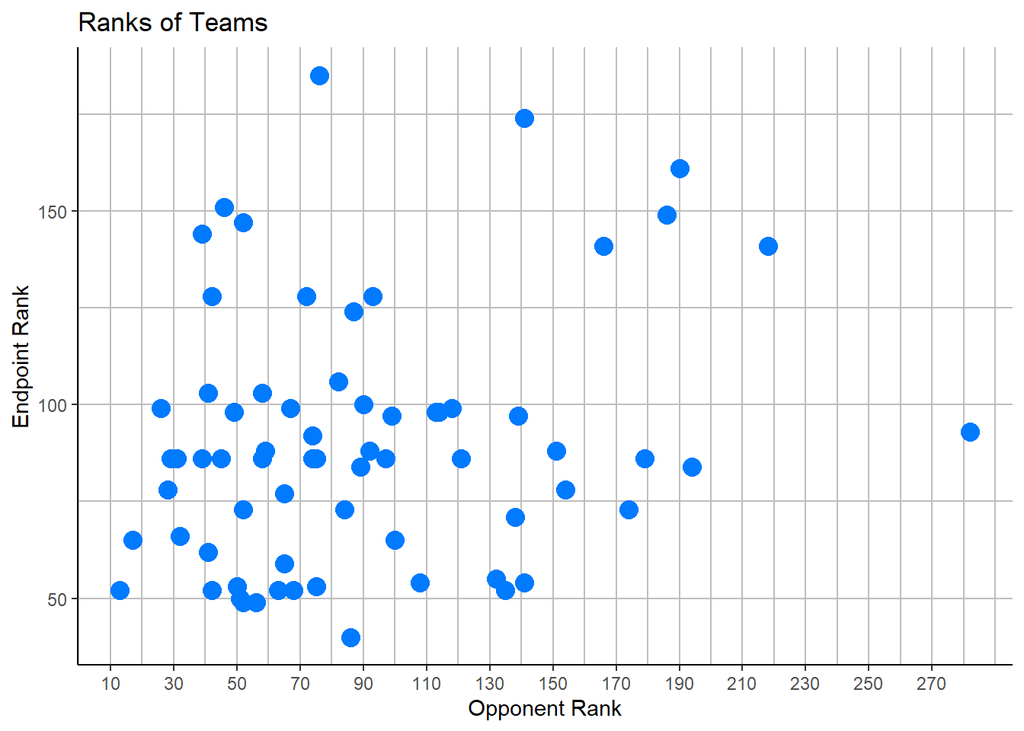

```r
#plot the Rank of Endpoint Rank against the Rank of their Opponent across
plottitle  <-  'Ranks of Teams'
xlab  <-  'Opponent Rank'
ylab  <-  'Endpoint Rank'
pointsize  <-  4 #change this number to alter point size

#Select which variables we want to compare
rank_comparison <- df %>% select(`Rank 1`, `Rank 2`)
#Changing the value type
rank_comparison$`Rank 1` <- as.numeric(as.character(rank_comparison$`Rank 1`))
rank_comparison$`Rank 2` <- as.numeric(as.character(rank_comparison$`Rank 2`))

#Order by rank
p1 <- ggplot(rank_comparison, aes(x =  `Rank 2`,y = `Rank 1`))
p1 + geom_point() +
#Set the background to white, gridlines to grey and the data points to Endpoint's offical blue colour "#007AFF"
  theme_classic() +
   theme(
    panel.grid.major = element_line(colour = "grey"),
    panel.grid.minor = element_line(colour = "grey")) +
  geom_point(color="#007AFF", size = pointsize) +
  ggtitle(plottitle) +
  #Order and Scale the axis so they're more visually appealing
  scale_x_continuous(breaks = seq(10, max(rank_comparison$`Rank 2`), by = 20), ) +
  xlab(xlab) + ylab(ylab)
```

```r
#save output
ggsave('ranks.png')
```

## Visualisation 2 - Endpoint’s Win Rate

**2. What’s Endpoint’s overall percentage win rate?** To find out Endpoint’s percentage win rate, we need to define what a ‘Win’ is and summate all the data from the ‘Results’ column.

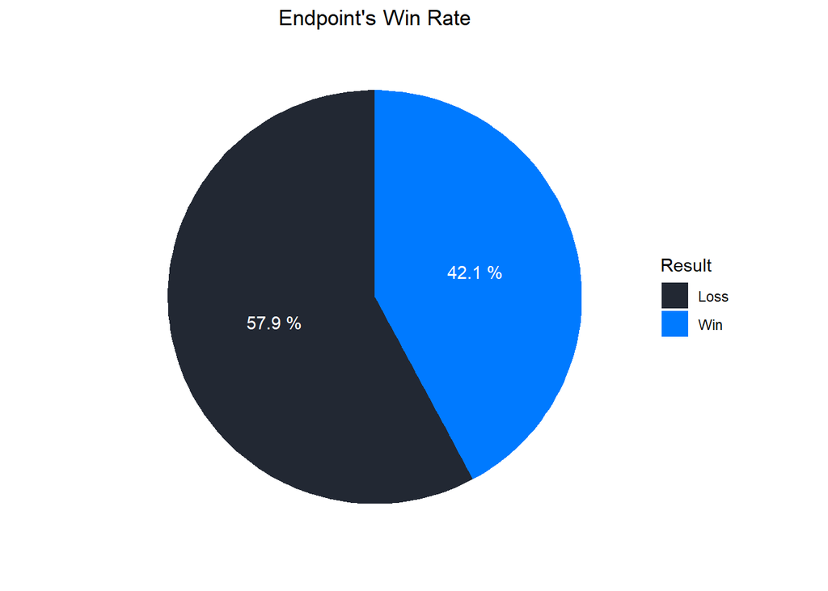

```r
#defining what a 'win' is using an if statement
winrate <- df %>% select(`Team 1`,`Winner`)
winrate <- mutate(winrate, Result = ifelse(`Winner` < 2, "Win", "Loss"), )
winrate <- mutate(winrate, Count =1)

#Collating 'result' with our definition of winrate
table = data.table(winrate)
table = table[, sum(Count), by = `Result`]
summaryDf = as.data.frame(table)

#plot the pie chart
pie = ggplot(table, aes(x="", y=V1, fill=factor(Result))) + geom_bar(stat="identity", width=1)
pie <- pie + coord_polar("y", start=0) +
   #using Endpoint's official colours
  scale_fill_manual(values=c("#222833", "#007AFF")) +
  labs(fill = "Result",
       x = "",
       y = "",
       title = "Endpoint's Win Rate") +
  theme_classic()+
#Change background to white, aligning percentages in the centre, hiding the axis and grid lines
theme(plot.title = element_text(hjust=0.5),
        axis.line = element_blank(),
        axis.text = element_blank(),
        axis.ticks = element_blank()) +
  #add labels to the chart with percentages
  geom_text(aes(label = paste(round(V1 / sum(V1) * 100, 1), "%")),
            position = position_stack(vjust = 0.5),color="white")
pie
```

```r
#save output
ggsave('winrate.png')
```

Endpoint have a win rate of 42.1%, under half. This doesn’t sound impressive on paper, but when we consider that they are the only Globally Ranked UK team it isn’t bad. That’s my opinion and perhaps I’m biased though!

Future studies should consider comparing Endpoint’s winrate against other teams to properly understand what is a good or bad winrate.

## Visualisation 3 - Win Rate vs. Map Type

**3. How do Endpoint preform on different maps?** In CS:GO, you can play on a range of different map layouts in casual play and in professional tournaments. Anecodadly, players usually have a favourite map or one they think they preform poorly on. Professional teams often spend hours training on these maps, so it would be interesting to see if Endpoint should have any biases towards certain maps.

To do this, the ‘Result’ and ‘Map’ data neets collecting, and the definition of what a Win is needs to be defined again.

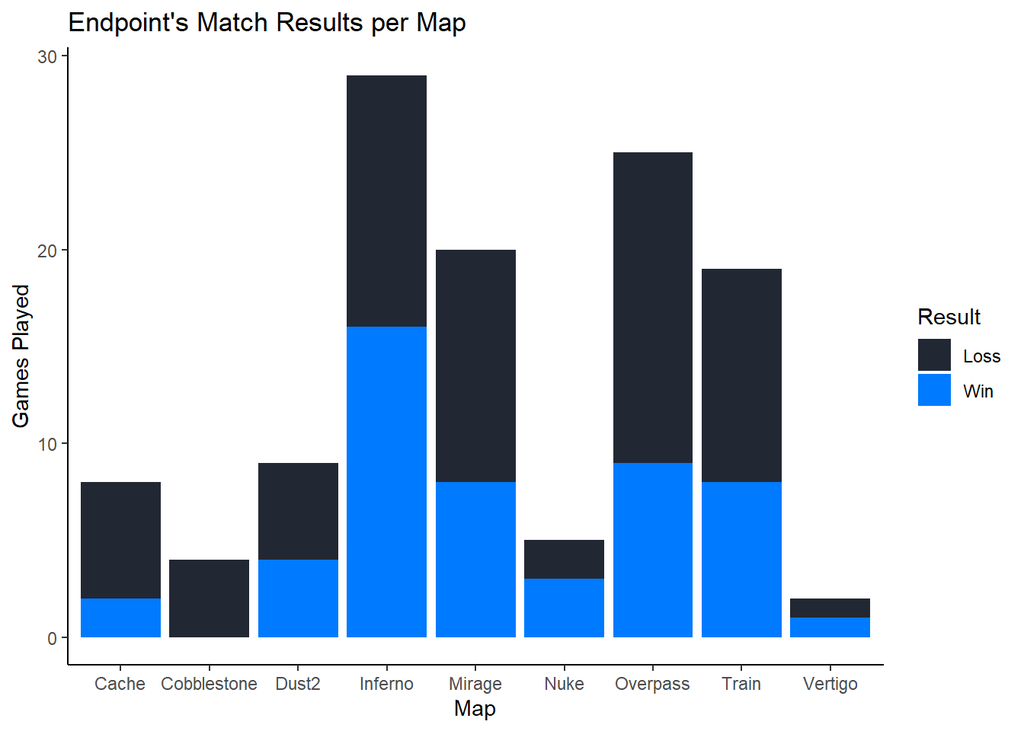

```r
#collating map and win data
map_scores <- df %>% select(`Map`,`Winner`)
#defining what a 'win' is using an if statement
maprate <- mutate(map_scores, Result = ifelse(`Winner` < 2, "Win", "Loss"), )
#selecting to plot 'Map' and 'Result' columns only
results <- maprate %>% select(`Map`,`Result`)
#Adding a count so a total win rate is displayed
results <- mutate(results, `Games Played` = 1 )

#Plot the bar chart
plottitle2  <-  "Endpoint's Match Results per Map"
p <- ggplot(results, aes(fill=Result, y=`Games Played`, x=Map)) +
  geom_bar(position="stack", stat="identity") + ggtitle(plottitle2) +
  theme_classic() #change background to white
#using Endpoint's colours
p +scale_fill_manual(values=c("#222833","#007AFF"))
```

```r
#save output
ggsave('Mapresults.png')
```

This barchart displays a significant weakness of this dataset (or perhaps of Endpoint), as there isn’t a remotley equal amount of playtime across each maps. For example, they appear to preform poorly on **Cobblestone** however, they’ve only played this map a few times compared to **Inferno** which they’ve played nearly 30 times. This makes it difficult to compare which maps Endpoint preform best on as the frequency they play them is not equal.

Therefore, we can perhaps conclude that Endpoint would be best playing the maps they have played the most frequently and thus have more experience with: **Inferno, Mirage, Overpass and Train**. Though their Loss rate is still high for these maps, they have far more experience with them compared to other maps. If they played maps sucgh as **Cache, Cobblestone, Nuke and Vertigo**, they may not preform well as they have played them so infrequently in matches.

## Summary

The research questions I hoped to answer have been well answered through my analysis and visualisations however, further work is required. As stated previously, I have only considered the match data from Endpoint’s matches so future analysis should consider the data from *all teams*. This would be interesting in terms of comparing the experience level and win rate of Endpoint to other Gloabally Ranked teams.

Additionally, I only used *results.csv* in my analysis, future researchers may wish to examine the other 3 data files. Of particular interest personally, is *players.csv*, which contains information about individual professional player statistics. In keeping with my dissertation, it could be interesting to examine how individual player experience effects the team match results and their personal win rate.

## Further Notes

I’ve really enjoyed doing this analysis! It was fun to use a dataset which is so relevant to something I’m working on at the moment, and has provided me with more insight into the professional CS:GO world. Professional players use match statistics to improve their gameplay, so it is interesting to see what kind of insights this data provides for myself.

This page and the analysis was generated using R.  
The repo (including the rmakdown file, data, plots and image files) are availble online via github: https://github.com/EleanorHyde/CS_GO_Data